# GenetikaX assignment

```python
import pandas as pd
import numpy as np
import matplotlib.pyplot as plt
import seaborn as sns
```

```python
var_names = {
    "ID": "Patient ID",
    "HSOIN": "HRS Initial insomnia",
    "HMNIN": "HRS Middle insomnia",
    "HEMIN": "HRS Delayed insomnia",
    "HMDSD": "HRS Depressed mood",
    "HPANX": "HRS Psychic anxiety",
    "HINSG": "HRS Loss of insight",
    "HAPPT": "HRS Appetite",
    "HWL": "HRS Weight loss",
    "HSANX": "HRS Somatic anxiety",
    "HHYPC": "HRS Hypochondriasis",
    "HVWSF": "HRS Guilt feelings and delusions",
    "HSUIC": "HRS Suicide",
    "HINTR": "HRS Work and interests",
    "HENGY": "HRS Somatic energy",
    "HSLOW": "HRS Retardation",
    "HAGIT": "HRS Agitation",
    "HSEX": "HRS Libido",
    "HDTOT": "Total Pre Treatment Depression Score",
    "SPANISH": "English/Spanish",
    "RESID": "Current residence",
    "RTOWN": "Rent or own current residence",
    "RESY": "Years lived at residence",
    "RESM": "Months lived at residence",
    "MARIT": "Current marital status",
    "SPOUS": "Spouse/partner lives with patient",
    "RELAT": "Number of relatives living with patient",
    "FREND": "Number of friends living with patient",
    "THOUS": "Total number of persons in household",
    "SCHOOL": "Years of schooling completed",
    "DEGREE": "Highest degree received",
    "STUDENT": "Currently a student",
    "EMPL": "Current employment status",
    "VOLUN": "Currently do volunteer work",
    "LEAVE": "On medical or psychiatric leave",
    "MEDICARE": "Medicare",
    "MEDICAID": "Medicaid",
    "PRIVINS": "Private insurance",
    "MKEDC": "Better able make important decisions",
    "ENJOY": "Better able to enjoy things",
    "FAMIM": "Impact of your family and friends",
    "DEPRESSION SCORE PERCENT IMPROVEMENT": "target"
}
```

```python
demographics = pd.read_excel('1_demographics_GenetikaExercise_Confidential.xlsx', na_values=[' ']).set_index('ID')
symptoms = pd.read_excel('2_symptoms_GenetikaExercise_Confidential.xlsx', na_values=[' ']).set_index('ID')
score = pd.read_excel('3_dependant_GenetikaExcercise_Confidential.xlsx').set_index('ID')
```

```python
score.shape, symptoms.shape, demographics.shape
```

```
((7989, 2), (1952, 19), (1953, 22))
```

```python
feature_matrix = pd.merge(symptoms, demographics, how='outer', left_index=True, right_index=True)
```

Dependent variable is a mini time-series per patient. How do we work with this? Simplest is to take a representative statistic like max or mean, even though this means discarding information. Another option would be to take the diff between min and max (positive or negative depending on which came first). Another possibility would be to train separate models per patient and then aggregate them.

```python
target = score.groupby('ID')['DEPRESSION SCORE PERCENT IMPROVEMENT'].max()
```

Whoops, didn't read the prompt properly...but leaving this here since I think it's still relevant!  
OK it's a classification problem, let's label them

```python
def is_improved(ser):
    "Label True if improved, otherwise False"
    return (ser > 50).any()
```

```python
target = score.groupby('ID')['DEPRESSION SCORE PERCENT IMPROVEMENT'].apply(is_improved)
```

```python
target.value_counts()
```

```
True     1209
False     710
Name: DEPRESSION SCORE PERCENT IMPROVEMENT, dtype: int64
```

Are some columns shadowing each other? Let's look at simple Pearson correlation. (Plot is larger, best viewed in a separate browser tab.)

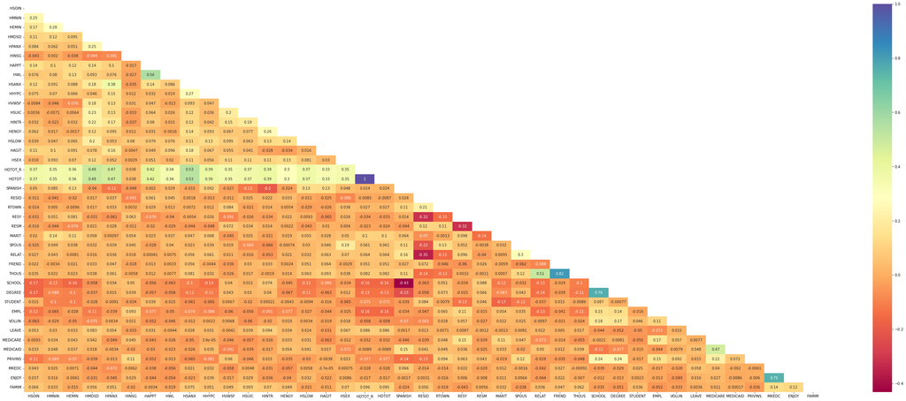

```python
a = feature_matrix.corr()
lower_t = a.where(np.tril(np.ones(a.shape), k=-1).astype(bool))
f, ax = plt.subplots(figsize=(50,20))
sns.heatmap(lower_t, cmap="Spectral", ax=ax, annot=True);
```

```python
to_drop = [column for column in lower_t.columns if any(lower_t[column] > 0.8)]
to_drop
```

```
['HDTOT_R', 'FREND']
```

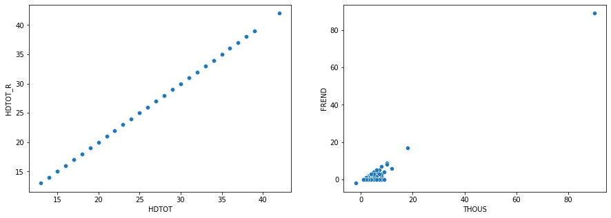

```python
f, (ax1, ax2) = plt.subplots(1, 2, figsize=(15,5))
sns.scatterplot(x='HDTOT', y='HDTOT_R', data=feature_matrix, ax=ax1)
sns.scatterplot(x='THOUS', y='FREND', data=feature_matrix, ax=ax2);
```

The left pair is identical. The right pair is not, but pretty closely correlated. Let's drop the first.

```python
feature_matrix = feature_matrix.drop(columns=to_drop[0])
```

Looking at number of unique values and feature names, we'll choose which ones are numeric vs categorical, and one-hot encode (dummy variables) the latter.

```python
{var_names[c]: feature_matrix[c].nunique() for c  in feature_matrix.columns}
```

```
{'HRS Initial insomnia': 3,
 'HRS Middle insomnia': 3,
 'HRS Delayed insomnia': 3,
 'HRS Depressed mood': 5,
 'HRS Psychic anxiety': 5,
 'HRS Loss of insight': 3,
 'HRS Appetite': 4,
 'HRS Weight loss': 4,
 'HRS Somatic anxiety': 5,
 'HRS Hypochondriasis': 4,
 'HRS Guilt feelings and delusions': 5,
 'HRS Suicide': 5,
 'HRS Work and interests': 5,
 'HRS Somatic energy': 3,
 'HRS Retardation': 4,
 'HRS Agitation': 5,
 'HRS Libido': 3,
 'Total Pre Treatment Depression Score': 28,
 'English/Spanish': 2,
 'Current residence': 8,
 'Rent or own current residence': 4,
 'Years lived at residence': 54,
 'Months lived at residence': 15,
 'Current marital status': 6,
 'Spouse/partner lives with patient': 3,
 'Number of relatives living with patient': 10,
 'Number of friends living with patient': 13,
 'Total number of persons in household': 14,
 'Years of schooling completed': 29,
 'Highest degree received': 7,
 'Currently a student': 3,
 'Current employment status': 6,
 'Currently do volunteer work': 4,
 'On medical or psychiatric leave': 3,
 'Medicare': 5,
 'Medicaid': 5,
 'Private insurance': 5,
 'Better able make important decisions': 6,
 'Better able to enjoy things': 6,
 'Impact of your family and friends': 8}
```

```python
numeric_cols = [
    "Total Pre Treatment Depression Score",
    "Years lived at residence",
    "Months lived at residence",
    "Number of relatives living with patient",
    "Number of friends living with patient",
    "Total number of persons in household",
    "Years of schooling completed",
    "target",
]
numeric_cols = [{v: k for k, v in var_names.items()}[x] for x in numeric_cols]
```

```python
categ_cols = list(set(feature_matrix.columns).difference(numeric_cols))
```

Some decisions about the data:

- Fill NaN values with the mode. Could have also gone with a special numeric value as a category for "missing". Could also have done imputation since not too much missing data.
- Decided not to standardise the numeric columns. Can help with interpreting the model, but for now we're just looking for correlations with the target

```python
for c in feature_matrix.columns:
    feature_matrix[c] = feature_matrix[c].fillna(feature_matrix[c].mode()[0])
```

One-hot encoding the categorical variables

```python
dummy_matrix = pd.get_dummies(feature_matrix, columns=categ_cols)
```

```python
from sklearn.linear_model import LogisticRegression, Lasso
from sklearn.model_selection import train_test_split, cross_val_score
from sklearn.feature_selection import SelectFromModel
from sklearn.ensemble import RandomForestClassifier
from sklearn.metrics import log_loss
```

```python
from sklearn.model_selection import KFold
from sklearn.model_selection import cross_val_predict
```

```python
X = pd.merge(dummy_matrix, target, how='right', left_index=True, right_index=True).iloc[:, :-1]
y = target
```

```python
for col in X.columns:
    if '_' in col:
        name, value = col.split('_')
        X = X.rename(columns={col: var_names[name] + ' = ' + value})
    else:
        X = X.rename(columns={col: var_names[col]})
```

```python
X_train, X_test, y_train, y_test = train_test_split(X.fillna(0), y, test_size=0.15)
```

First model: random guessing:

```python
log_loss(y_test, np.random.choice([1, 0], size=len(X_test)))
```

```
18.109041705120674
```

```python
score_func = lambda predictor: log_loss(y_test, predictor.predict(X_test))
```

Logistic regression with L1 regularisation.

```python
log_model = LogisticRegression(max_iter=1e3, penalty='l1', solver='liblinear')
log_model.fit(X_train, y_train)
score_func(log_model)
```

```
12.832345280701908
```

With cross validation:

```python
logreg = LogisticRegression(max_iter=1e3, penalty='l1', solver='liblinear')
predicted = cross_val_predict(logreg, X, y, cv=5)
log_loss(y, predicted)
```

```
12.86901517114508
```

Using a random forest with default params is roughly the same. Could grid search to find better parameters.

```python
rf_clf = RandomForestClassifier()
rf_clf.fit(X_train, y_train)
score_func(rf_clf)
```

```
12.952285469528512
```

With cross validation:

```python
rf_clf_2 = RandomForestClassifier()
predicted = cross_val_predict(rf_clf_2, X, y, cv=5)
log_loss(y, predicted)
```

```
12.599057452318075
```

We used LASSO (L1) regularisation in the logistic regression model, which is good for feature selection since it zeroes a lot of the weights. We can extract the features with higher weights in this model.

```python
lasso_feats = [col for val, col in zip(SelectFromModel(log_model, prefit=True).get_support(), X.columns) if val]
len(lasso_feats)
```

```
98
```

```python
lasso_feats[:30]
```

```
['Years lived at residence',
 'Months lived at residence',
 'Number of relatives living with patient',
 'Number of friends living with patient',
 'Years of schooling completed',
 'HRS Middle insomnia = 0.0',
 'HRS Middle insomnia = 2.0',
 'HRS Hypochondriasis = 0.0',
 'HRS Hypochondriasis = 1.0',
 'HRS Hypochondriasis = 2.0',
 'HRS Work and interests = 0.0',
 'HRS Work and interests = 1.0',
 'HRS Work and interests = 3.0',
 'HRS Work and interests = 4.0',
 'Current marital status = 1',
 'Current marital status = 2',
 'Current marital status = 4',
 'Current marital status = 5',
 'Current marital status = 6',
 'Private insurance = -4',
 'Private insurance = -3',
 'Private insurance = 0',
 'Private insurance = 1',
 'Rent or own current residence = 1',
 'Rent or own current residence = 2',
 'Rent or own current residence = 3',
 'HRS Suicide = 1.0',
 'HRS Suicide = 2.0',
 'HRS Suicide = 3.0',
 'HRS Suicide = 4.0']
```

The random forest classifier also gives us feature importance:

```python
nb_features = pd.Series(rf_clf.feature_importances_, index=X.columns)
nb_features.sort_values(ascending=False).head(30)
```

```
Years lived at residence                   0.039504
Total Pre Treatment Depression Score       0.037556
Years of schooling completed               0.036166
Months lived at residence                  0.032657
Total number of persons in household       0.024658
Number of relatives living with patient    0.022040
Number of friends living with patient      0.011024
Private insurance = 1                      0.010603
HRS Depressed mood = 3.0                   0.010194
Current employment status = 3              0.009744
HRS Somatic anxiety = 2.0                  0.009741
HRS Hypochondriasis = 0.0                  0.009713
HRS Work and interests = 3.0               0.009585
HRS Agitation = 1.0                        0.009565
HRS Guilt feelings and delusions = 2.0     0.009479
HRS Psychic anxiety = 2.0                  0.009365
HRS Suicide = 1.0                          0.009266
HRS Initial insomnia = 2.0                 0.009133
Current residence = 1                      0.009079
HRS Delayed insomnia = 2.0                 0.009074
HRS Work and interests = 2.0               0.008958
Impact of your family and friends = 2      0.008786
HRS Appetite = 1.0                         0.008744
HRS Appetite = 0.0                         0.008738
HRS Somatic anxiety = 1.0                  0.008730
HRS Middle insomnia = 1.0                  0.008697
HRS Delayed insomnia = 0.0                 0.008671
HRS Psychic anxiety = 3.0                  0.008629
HRS Retardation = 1.0                      0.008617
HRS Libido = 2.0                           0.008605
dtype: float64
```

## Scratchpad

```python
score.groupby('ID')['week'].count().value_counts().sort_index()
```

```
1    113
2    149
3    253
4    456
5    724
6    199
7     20
8      4
9      1
Name: week, dtype: int64
```

```python
score['DEPRESSION SCORE PERCENT IMPROVEMENT'].min(), score['DEPRESSION SCORE PERCENT IMPROVEMENT'].max()
```

```
(-5, 100)
```